# df_dnqp

```python
#imports
import numpy as np
import matplotlib.pyplot as plt
from scipy import constants as c
from scipy import special
from scipy.optimize import curve_fit

pi = c.pi
k = c.k #J/K
hbar = c.hbar #J.s

N0 = 1.45e47 # 1/(J.m^3) #density of states at Fermi level for Al (https://journals.aps.org/prb/abstract/10.1103/PhysRevB.77.100501)
N0 = N0*1e-18 #m^-3 -> um^-3
```

This notebook is to calculate ${df\over dn_{qp}}$. Recall that $${\delta f \over f} = {\alpha \gamma \over 2}\cdot {\delta \sigma_2 \over \sigma_2},$$ and we can simplify $$\delta \sigma_2 = {d\sigma_2 \over dT}{dT\over d n_{qp}}\delta n_{qp} = {d\sigma_2\over dn_{qp}}\delta n_{qp},$$ where ${dT\over dn_{qp}} = \left(dn_{qp}\over dT\right)^{-1}$. (This is easy to calculate since $n_{qp}(T)=2N_0\sqrt{2\pi kT\Delta_0}e^{-{\Delta_0\over k T}}.$ This gives

$${\delta f \over \delta n_{qp}} = -{\alpha \gamma \over 2}\cdot {f_0\over \sigma_2} \cdot {d\sigma_2\over dn_{qp}}.$$

I'll use standard numerical values for Al: $f_0 = \omega_0/2\pi = 1$GHz, $\alpha = .1$, $T_c = 1.2$K, $\Delta_0 = 1.76kT_c$, $T = 10$mK, $\gamma = -1/2$, and work constructively towards the final expression.

```python
def nqp(T,Delta0):
    return 2*N0*np.sqrt(2*pi*k*T*Delta0)*np.exp(-Delta0/(k*T))

def nqp_prime(T,Delta0):
    return 2*N0*((pi*k*Delta0/np.sqrt(2*pi*k*T*Delta0)) + \
                 (Delta0/(k*T**2))*np.sqrt(2*pi*k*T*Delta0)*\
                 np.exp(-Delta0/(k*T)))
```

For convenience, define $\xi = {\hbar \omega \over kT}$. We start with

$${\sigma_2(T)\over \sigma_n}={\pi\Delta_0\over \hbar\omega}\left(1-\sqrt{2\pi kT\over \Delta_0}e^{-\Delta_0\over kT}-2e^{-\Delta_0\over kT}e^{-\xi}I_0(\xi)\right)$$

$\sigma_n$ will cancel, so I'll ignore it.

```python
def sigma_2(T, Delta0, omega):
    xi = hbar*omega/(k*T)
    #print('hbar omega/kT = ', xi)
    second_term = np.sqrt(2.*pi*k*T/Delta0)*np.exp(-Delta0/(k*T))

    third_term = 2.*np.exp(-Delta0/(k*T))*np.exp(-xi)*special.i0(xi)

    result =  (pi*Delta0/(hbar*omega))*(1.-second_term - third_term)
    #print('sigma2 = ',result)
    return result
```

Gao gives the equation

$${1\over \sigma_n}{d\sigma_2\over dn_{qp}}=-{\pi\over 2N_0\hbar\omega}\left(1+\sqrt{2\Delta_0\over \pi k_BT}e^{-\xi}I_0(\xi){\left\lbrace{\Delta_0\over k T}+\xi\left(1-{I_1(\xi)\over I_0(\xi)}\right)\right\rbrace\over {\Delta_0\over kT}+{1\over 2}}\right),$$

which is for quasiparticles acquired due to temperature change. Although, he showed that this is equivalent up to a factor of unity to quasiparticles acquired to pair breaking. I'm going to assume $kT \ll \hbar \omega$, so $I_1/I_0 \sim 1$. This gives

$${1\over \sigma_n}{d\sigma_2\over dn_{qp}}=-{\pi\over 2N_0\hbar\omega}\left(1+\sqrt{2\Delta_0\over \pi k_BT}e^{-\xi}I_0(\xi){{\Delta_0\over k T}\over {\Delta_0\over kT}+{1\over 2}}\right),$$

```python
def sigma_2_prime(T, Delta0, omega):
    xi = hbar*omega/(k*T)
    v = Delta0/(k*T)
    #print('Delta0/kT = ', v)
    a = np.sqrt(2.*Delta0/(pi*k*T))
    b = np.exp(-xi)*special.i0(xi)
    c = (Delta0/k*T)/((Delta0/k*T) + .5)
    term = a*b*c
    d = -(pi/(2.*N0*hbar*omega))
    result =  d*(1. + term)
    #print('sigma2 prime = ', result);
    return result
```

Now, I'm going to write the final function, and see the numbers we get out of this.

```python
gamma = -.5
alpha = .1
Tc = 1.2 #K
Delta0 = 1.764*k*Tc

def df_dnqp(T,f0):
    omega0 = 2*pi*f0
    return (-alpha*gamma/2.)*(f0/sigma_2(T,Delta0, omega0))*sigma_2_prime(T,Delta0, omega0)
```

```python
T = .01 #K
f0 = 1e9 #Hz

dfdnqp = df_dnqp(T,f0)

print('df/dnqp(10mK, 1GHz) = ', df_dnqp(T,f0), ' Hz/qp um^3')
```

```
df/dnqp(10mK, 1GHz) =  -3.210622895653631  Hz/qp um^3
```

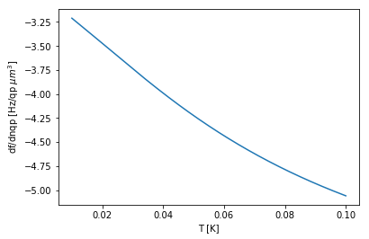

```python
T = np.linspace(.01, .1, 1000)
f0 = 1e9
r = df_dnqp(T, f0)
plt.plot(T,r)
plt.ylabel(r'df/dnqp [Hz/qp $\mu m^3$]')
plt.xlabel('T [K]')
plt.show()
```

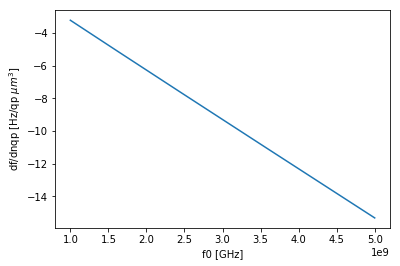

```python
T = .01
f = np.linspace(1e9, 5e9, 1000)
r = df_dnqp(T, f)
plt.plot(f,r)
plt.ylabel(r'df/dnqp [Hz/qp $\mu m^3$]')
plt.xlabel('f0 [GHz]')
plt.show()
```

From PB Thesis (and Gao): $\Delta(T) \approx \Delta_0\left(1 - {n_{qp}\over 2N_0\Delta(T)}\right).$

This implicitly defines an equation for $\Delta(T)$, and I want to find that equation.

We start by making a quadratic: $\Delta(T)^2 = \Delta_0(\Delta(T) - {n_{qp}\over 2N_0}) \Rightarrow \Delta(T)^2 - \Delta_0\Delta(T) + {n_{qp}\Delta_0\over 2N_0} = 0,$

and we use the quadratic formula to obtain

$$\Delta(T) = {\Delta_0 \over 2} \pm {\sqrt{\Delta_0^2 - 2{n_{qp} \Delta_0\over N_0}}\over 2}.$$

I want to expand the square root term when $n_{qp}/N_0 \ll 1$.

$$ \sqrt{\Delta_0^2 - 2{n_{qp} \Delta_0\over N_0}} = \Delta_0\sqrt{1 - 2{n_{qp}\over N_0\Delta_0}} \approx \Delta_0\left(1 - {n_{qp} \over N_0\Delta_0}\right), $$

which shares the units of the original approximation.

Then, ignoring the subtracting solution, we have $\Delta(T) = \Delta_0\left(1 - {2n_{qp}\over N_0\Delta_0} \right)$, which is intuitive given the original approximation.

PB Thesis gives $$\tau_{qp} = {\tau_0\over\sqrt{\pi}} \cdot \left(kT_c\over 2\Delta(T)\right)^{5/2}\sqrt{T_c\over T}e^{\Delta(T)\over kT} = {1\over Rn_{qp}},$$

where $$R^{-1}=N_0\tau_0\cdot {(kT_c)^3\over 2\Delta(T)^2},$$ the units of $R$ being m$^3$s$^{-1}$. $\tau_0$ is a material parameter. Then, we have $N_{qp}\tau_{qp} = {V\over R}$ has units of seconds, which is the quantity we wish to measure.

The problem is that there are not enough equations to fit for $R$ and $\tau_0$ simultaneously, so I'll estimate $\tau_0 = 2.5 \times 10^{-6}$ seconds as the value that causes $1/Rn_{qp}$ to agree with $\tau_{qp}$.

```python
#tau_0 fitting

def nqp(T):
    return 2*N0*np.sqrt(2*pi*k*T*Delta0)*np.exp(-Delta0/(k*T))

def Delta(nqp):
    return Delta0*(1 - (2.*nqp/(N0*Delta0)))

def tau_qp(T, tau0):
    n_qp = nqp(T)
    delta = Delta(n_qp)
    return (tau0/np.sqrt(pi) * (k*Tc/(2.*delta))**(5./2.)*np.sqrt(Tc/T)*np.exp(delta/(k*T)))
```

```python
#ballpark noise floor estimate
#noise_floor = nqp * V * tau_qp

stage_temp = .120 #K #model breaks down at very low T
T = stage_temp
tau_0 = 10**(-5.6) #sec
V = 2000e-18 #um^3 = 10^-18 m^3
f0_dev = 600e6 #Hz
num_qp = nqp(T)
tauqp = tau_qp(T, 10**(-5.9))

print(f'tau_0 = {tau_0}s')

R = N0*tau_0*(k*Tc)**3/(2*Delta(num_qp)**2)
print(f'R = {R} m^3/s')

noise_floor = V/R*np.abs(df_dnqp(T, f0_dev))
print(f'Sxx = {noise_floor} 1/sqrt(Hz)')
```

```
tau_0 = 2.5118864315095823e-06s
R = 0.9696282675466535 m^3/s
Sxx = 6.939343070798918e-15 1/sqrt(Hz)
```

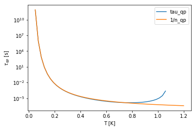

```python
T = np.linspace(.05,1.2)

plt.semilogy(T, tau_qp(T, tau_0), label = 'tau_qp')
plt.semilogy(T, 1./(R*nqp(T)), label = '1/n_qp')
plt.xlabel('T [K]')
plt.ylabel(r'$\tau_{qp}$ [s]')
plt.legend()
plt.show()
```

Now, let's compare this number to the real data.

```python
PSD = np.genfromtxt('KID_001_Temp=015mK_Att=20dB.txt', skip_header = 1, delimiter = ',')
```

```python
freqs = PSD[:,0]
PSDee = PSD[:,1]
```

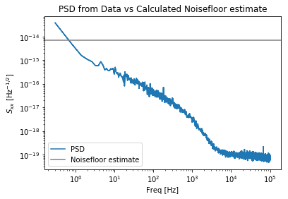

```python
plt.loglog(freqs, PSDee, label = 'PSD')
plt.axhline(noise_floor, color = 'gray', label = 'Noisefloor estimate')
plt.xlabel("Freq [Hz]")
plt.ylabel(r'$S_{xx}$ [Hz$^{-1/2}$]')
plt.title('PSD from Data vs Calculated Noisefloor estimate')
plt.legend()
```

This is clearly quite high. Now, I'll compare this to a stochastic estimate where we view $n_{qp}$ as a Poisson random variable to create a "timestream" of random numbers.

```python
#Stochastic functions
def Sxx(T, f0, nqp):
    return np.abs(np.fft.fft(df(T, f0, nqp)))**2

def df(T, f0, nqp):
    return df_dnqp(T, f0)*delta_nqp(nqp, T)

def expected_nqp(T):
    return 2*N0*np.sqrt(2*pi*k*T*Delta0)*np.exp(-Delta0/(k*T))

def delta_nqp(nqp, T):
    return nqp - expected_nqp(T)
```

```
Text(0.5,1,'Stochastic Model vs Calculated Sxx_0 Level')
```

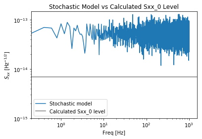

```python
#set nqp value
expected_nqp_value = nqp(stage_temp)
for mean_nqp in [expected_nqp_value]:
    Sxx_array = []
    Freq = []
    for r in [i for i in range(0,12)]:
        np.random.seed(r)
        #get poisson data
        n_qp = np.random.poisson(mean_nqp, len(freqs))

        f0 = 1e9

        #get PSD
        sxx = (1/f0**2)*Sxx(.01, f0, n_qp)
        freq = np.fft.fftfreq(len(sxx), d = 1./2000.)

        ind = np.where(freq >= 0);
        freq = freq[ind]; sxx = sxx[ind]

        freq = np.delete(freq, 0); sxx = np.delete(sxx, 0)

        Freq.append(freq); Sxx_array.append(sxx)

    #average over PSDs
    sxx_avg = 0.
    for s in Sxx_array:
        sxx_avg += s**2
    sxx_avg = np.sqrt(sxx_avg)
plt.loglog(Freq[0], sxx_avg, label = f'Stochastic model')
plt.axhline(noise_floor, color='gray', label = 'Calculated Sxx_0 level')
plt.legend()
plt.xlim(left = 0)
plt.xlabel('Freq [Hz]')
plt.ylabel(r'$S_{xx}$ [Hz$^{-1/2}$]')
plt.ylim(bottom = 1e-15)
plt.title('Stochastic Model vs Calculated Sxx_0 Level')
```

```
Text(0.5,1,'Stochastic Model and Calculated Sxx_0 Level with Data')
```

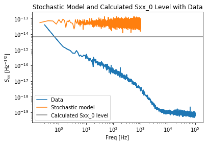

```python
plt.loglog(freqs, PSDee, label = 'Data')
plt.loglog(Freq[0], sxx_avg, label = f'Stochastic model')
plt.axhline(noise_floor, color='gray', label = 'Calculated Sxx_0 level')
plt.legend()
plt.xlabel('Freq [Hz]')
plt.ylabel(r'$S_{xx}$ [Hz$^{-1/2}$]')

plt.title('Stochastic Model and Calculated Sxx_0 Level with Data')
```